# Theory on Time series

Data obtained from observations collected sequentially over time are extremely common [1].

**Time series analysis** is the effort of extracting insightful summary and statistical information from observations arranged in chronological order [2].

several possible objectives in analysing a time series [2]:

- description
  - look for outliers; robust methods to be insensitive to outliers are needed
  - sudden or gradual changes in the series: **seasonal changes**, **step changes**, **turning points**
- explanation
  - use one time series to explain another
- prediction
  - use existing time series data to predict future obs. of the time series
- control
  - assess and maintain/control performances of processes

# concepts

- **deterministic**: if a time series can be predicted exactly
- **stochastic**: a sequence of random variables $Y_t: t=0, 1,2, \dots$
  - future obs. are partially determined by past obs.
  - so that future values have a probabilistic distribution conditioned on past values.
- **autocovariance function**, $\gamma_{t,s}=Cov(Y_t, Y_s)$ for time point t and s
  - $\gamma_{t,t}=Var(Y_t)$
  - $\gamma(t,s)=\gamma(s,t)$
  - $|\gamma_{t,s}|\le \sqrt{\gamma_{t,t} \gamma_{s,s}}$
  - $\gamma_k=\frac{\sum_{t=1}^{N-k}(y_t-\bar{y})(y_{t+k}-\bar{y}))}{N}, k=0,1,2,\dots$ gives the **autocovariance coefficients at lag k** between obs. that are k steps apart.
- **autocorrelation function**, $\rho_{t.s}=Corr(Y_t, Y_s)$ for time point t and s
  - $\rho_{t,t}=1$
  - $\rho_{t,s}\le 1$
  - $\rho_1=\frac{\sum_{t=1}^{N-1}(y_t-\bar{y})(y_{t+1}-\bar{y}))}{\sum_{t=1}^{N}(y_t-\bar{y})^2}$
  - $\rho_k=\frac{\sum_{t=1}^{N-k}(y_t-\bar{y})(y_{t+k}-\bar{y}))}{\sum_{t=1}^{N}(y_t-\bar{y})^2}, k=0,1,2,\dots$ gives the **sample autocorrelation coefficient at lag k** between obs. that are k steps apart.
  - $\rho_k=\gamma_k/\rho_0$
- time series classification
  - **continuous**: obs. are made continuously even the response takes only a discrete set of values
  - **discrete**: obs. are taken at specific times, such as equally spaced, even the response is continuous
    - arises in several ways: sampled at equal time intervals; aggregate/accumulate the values over equal intervals of time such as daily rainfalls
- assumptions to simplify time series data structure
  - stationarity
    - if the joint distribution of $Y_{t_1}, Y_{t_2}, \dots, Y_{t_n}$ is the same as the join distribution of $Y_{t_1-k}, Y_{t_2-k}, \dots, Y_{t_n-k}$ for all time points $t_1, t_2, \dots, t_n$ and time lag k.

# examples

- first example: let $e_1, \dots, e_n$ be a sequence of iid random variables with mean 0 and variance $\sigma^2$
  - construct a time series as follows:

  $$\begin{aligned}
  Y_1&=e_1 \\
  Y_2&=e_1+e_2 \\
  \vdots \\
  Y_t &= e_1+e_2+\dots+e_t
  \end{aligned}$$
  or $Y_t=Y_{t-1}+e_t$ with initial condition $Y_1=e_1$. here we have $E[Y_t]=0, var[Y_t]=t\sigma^2$ where variance increases linearly with time t. covariance for $1 \le t \le s$, $\gamma_{t,s}=Cov(Y_t, Y_s)=\sum_{i=1}^{s}\sum_{j=1}^{t}Cov(e_i, e_j)=t\sigma^2$; the autocorrelation for the random walk is given as $\rho_{t,s}=\frac{\gamma_{t,s}}{\sqrt{\gamma_{t,t}\gamma_{s,s}}}=\frac{t\sigma^2}{\sqrt{t\sigma^2\cdot s\sigma^2}}=\sqrt{\frac{t}{s}}$ for $1 \le t \le s$.
  - realization of the auto-correlations:

  $$\rho_{1,2}=\sqrt{\frac{1}{2}}=0.707, \rho_{8,9}=\sqrt{\frac{8}{9}}=0.943
  \\
  \rho_{24,25}=\sqrt{\frac{24}{25}}=0.980,
  \rho_{1,9}=\sqrt{\frac{1}{9}}=0.333$$
  the obs. of Y at neighboring time points are more and more positively correlated as time goes by; the obs. of Y at distant time points are less and less correlated.

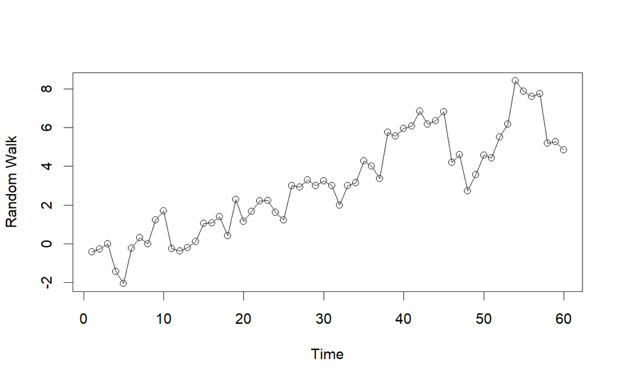

The simple random walk process provides a good approximation for phenomena as diverse as the movement of common stock price, and the movement of small particles in a fluid—so-called **Brownian motion**.

- second example: a moving average

let $\{Y_t\}$ be consisted if $Y_t=\frac{e_t+e_t-1}{2}$ where $e_i \overset{iid}{\sim} f(0, \sigma^2)$. $\mu_t=E[Y_t]=\frac{E(e_t)+E(e_{t-1})}{2}=0, var(Y_t)=\frac{\sigma^2}{2}, \gamma_{t,s}=\begin{cases}0.5 \sigma^2, |t-s|=0 \\ 0.25\sigma^2, |t-s|=1 \\ 0, |t-s|>1\end{cases}$ for all t, and $\rho_{t,s}=\begin{cases}1, |t-s|=0 \\ 0.5, |t-s|=1, \\ 0, |t-s|>1\end{cases}$.

note that $\rho_{2,1}=\rho_{3,2}=\rho_{4,3}=\rho_{9,8}=0.5$. $\rho_{3,1}=\rho_{4,2}=\rho_{t,t-2}$, and $\rho_{t,t-k}$ is the same for all t.

- third example

The classic Beveridge wheat price index series consists of the average wheat price in nearly 50 places in various countries measured in successive years from 1500 to 1869.

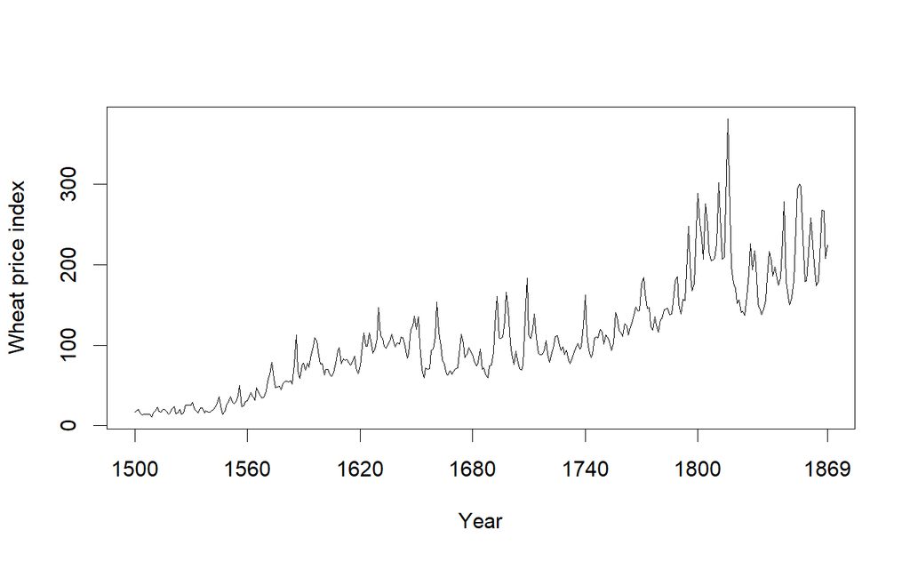

# descriptive techniques

```r
smooth.sym<-function(my.ts, window.q){
  window.size<-2*window.q+1
  my.ts.sm<-rep(0, length(my.ts)-window.size)
  for (i in 1:length(my.ts.sm)) {
  my.ts.sm[i]<-mean(my.ts[i:(i+window.size-1)])
  }
  my.ts.sm
} # moving average with equal and symmetric weights

smooth.spencer<-function(my.ts){
  weight<-c(-3,-6,-5,3,21,46,67,74,67,46,21,3,-5,-6,-3)/320
  my.ts.sm<-rep(0, length(my.ts)-15)
  for (i in 1:length(my.ts.sm)) {
    my.ts.sm[i]<-sum(my.ts[i:(i+14)]*weight)
    }
  my.ts.sm
} # Spencer’s 15-point moving average

bev.sm<-smooth.sym(bev, 7)
bev.spencer<-smooth.spencer(bev)
x.pos<-c(1500, 1560, 1620, 1680, 1740, 1800, 1869)
par(mfrow=c(3,1), mar=c(4,4,4,4))
plot(bev, type="l", xlab="Year", ylab="Index", xaxt="n")
axis(1, x.pos, x.pos)
```

```r
plot(c(1, length(bev)), c(0, max(bev)), type="n", xlab="Year",
ylab="Index", xaxt="n")
lines(seq(8, length(bev)-8), bev.sm)
```

```r
axis(1, x.pos-1500+1, x.pos)
plot(c(1, length(bev)), c(0, max(bev)), type="n", xlab="Year",
ylab="Index", xaxt="n")
```

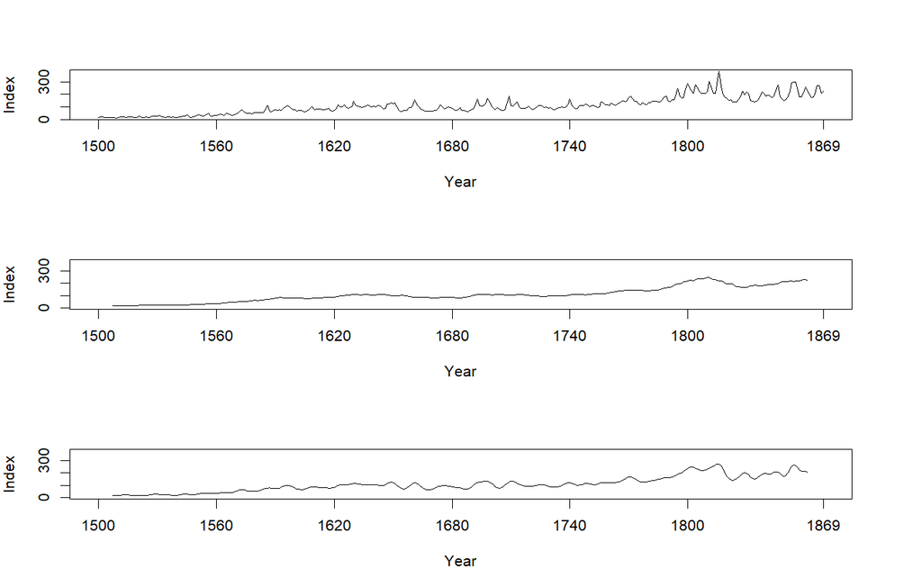

```r
lines(seq(8, length(bev)-8), bev.spencer)
axis(1, x.pos-1500+1, x.pos)
```

- transformation
  - stabilize the variance: transform when variance tend to increase with the mean
  - make seasonal effect additive
  - make data normally distributed

# model building strategy

- model specification: choose the classes of time series models that are appropriate for a given data series by looking at the time series plot and data collection processes
  - tentative and subject to revision
  - principle of parsimony
- model building: parameter estimation considering criteria such as least squares and ML
- model diagnostics: assessing quality of the model specified and estimated

1.

Cryer JD, Chan KS (2008) [Time series analysis: With applications in r](https://books.google.com/books?id=MrNY3s2difIC), Springer.

2.

Chatfield C, Xing H (2019) [The analysis of time series: An introduction with r](https://books.google.com/books?id=llupDwAAQBAJ), CRC Press.

3.

Nielsen A (2019) [Practical time series analysis: Prediction with statistics and machine learning](https://books.google.com/books?id=odCwDwAAQBAJ), O’Reilly Media.